# Sediment Source Modeling with Sandoval-Style Ratio Deconvolution

**AUTHOR**  
Rodrigo Kang

## Overview

This notebook implements a Sandoval-style ratio-based deconvolution workflow for the **Sediment Source Modeling** project.

The goal is to estimate the source fractions of artificial sediment mixtures using pairwise tracer ratios rather than matching tracer concentrations directly. The workflow is intentionally separated from the stochastic sediment fingerprinting notebook and from the McCaffrey-style constrained least-squares notebook so that the ratio-based approach can be evaluated as an independent deterministic baseline.

Unlike probabilistic source apportionment models, this method produces point estimates only. Its value is comparative and diagnostic: it tests whether relationships among selected tracers are sufficient to recover source proportions when the mixture problem is formulated in ratio space.

## Imports and Configuration

Paths and settings are centralised here. With the expected project layout, the notebook runs from the `python` directory, reads the project data from the sibling `data` directory, and stores all generated tables, figures, and evaluation results in the project-specific output directory:

`python/3-sediment-source-modeling-sandoval`

```python
from __future__ import annotations

from pathlib import Path
from typing import Iterable

import matplotlib.pyplot as plt
import numpy as np
import pandas as pd
from scipy.optimize import minimize


# Paths

notebook_dir = Path.cwd()
project_root = notebook_dir.parent if notebook_dir.name == "python" else notebook_dir

data_dir = project_root / "data"
input_processed_dir = data_dir / "processed"

output_dir = project_root / "python" / "3-sediment-source-modeling-sandoval"
figures_dir = output_dir / "figures"
tables_dir = output_dir / "tables"

for directory in [output_dir, figures_dir, tables_dir]:
    directory.mkdir(parents=True, exist_ok=True)


# Project settings

source_order = ["Subsurface", "Decontaminated", "Cropland", "Forest"]
random_seed = 42
rng = np.random.default_rng(random_seed)

plt.rcParams.update({
    "figure.figsize": (8, 5),
    "axes.spines.top": False,
    "axes.spines.right": False,
    "axes.grid": True,
    "grid.alpha": 0.25,
    "font.size": 10,
})
```

## Data Loading

The notebook uses the sediment fingerprinting data from the main project:

- **`mixture_proportions.csv`**: known source proportions for the artificial mixtures.
- **`fingerprint_data.csv`**: geochemical and colour fingerprint measurements for source samples and laboratory mixtures.
- **`selected_tracers.csv`**: tracer variables selected for source apportionment.

The ratio-based model is fitted in the positive tracer-concentration scale. When raw files are available, the selected tracers are read directly from the original data. If only the previously prepared log-transformed inputs are available, the notebook exponentiates them before constructing tracer ratios. This avoids taking ratios of logarithms, which would not preserve the original geochemical meaning of the measurements.

```python
def load_sediment_data(
    data_dir: Path,
    input_processed_dir: Path,
    source_order: list[str],
) -> tuple[pd.DataFrame, pd.DataFrame, pd.DataFrame, list[str]]:
    """
    Load positive-scale source signatures, mixture signatures, known proportions, and tracer names.

    Brief explanation:
    Prefer the raw project files when available. If they are not present, fall
    back to previously prepared log-transformed files and transform them back
    to the positive tracer scale before building tracer ratios.

    Inputs:
    data_dir : Path
        Directory containing the raw project CSV files.
    input_processed_dir : Path
        Directory containing previously prepared input CSV files.
    source_order : list[str]
        Ordered source names used throughout the analysis.

    Outputs:
    tuple[pd.DataFrame, pd.DataFrame, pd.DataFrame, list[str]]
        Source data, mixture data, true proportions, and selected tracer names.

    Author:
    Rodrigo Kang
    """
    raw_files_exist = all([
        (data_dir / "mixture_proportions.csv").exists(),
        (data_dir / "fingerprint_data.csv").exists(),
        (data_dir / "selected_tracers.csv").exists(),
    ])

    if raw_files_exist:
        proportions_raw = pd.read_csv(data_dir / "mixture_proportions.csv")
        fingerprints = pd.read_csv(data_dir / "fingerprint_data.csv")
        selected_tracers = pd.read_csv(data_dir / "selected_tracers.csv")["x"].tolist()

        source_name_map = {
            "source_s": "Subsurface",
            "source_d": "Decontaminated",
            "source_pf": "Cropland",
            "source_f": "Forest",
        }

        proportions = proportions_raw.rename(columns={
            "sediment_sample": "sample",
            "source_S": "Subsurface",
            "source_D": "Decontaminated",
            "source_PF": "Cropland",
            "source_F": "Forest",
        })
        proportions[source_order] = proportions[source_order].astype(float)

        sources = fingerprints.query("type == 'source'").copy()
        targets = fingerprints.query("type == 'target'").copy()

        sources["source_label"] = sources["source"].str.lower().map(source_name_map)

        if (fingerprints[selected_tracers] <= 0).any().any():
            raise ValueError("Selected tracers must be positive for ratio-based modelling.")

        source_df = sources[["sample", "source", "source_label"] + selected_tracers].copy()
        target_df = targets[["sample"] + selected_tracers].copy()

        truth = pd.concat([
            targets[["sample"]].reset_index(drop=True),
            proportions[source_order].reset_index(drop=True),
        ], axis=1)

    else:
        required_files = [
            input_processed_dir / "source_log_data.csv",
            input_processed_dir / "laboratory_mixture_log_data.csv",
            input_processed_dir / "known_source_proportions.csv",
        ]

        missing_files = [path.name for path in required_files if not path.exists()]
        if missing_files:
            raise FileNotFoundError(
                "Could not find raw input files or prepared log-transformed inputs. "
                f"Missing files: {missing_files}"
            )

        source_log_df = pd.read_csv(input_processed_dir / "source_log_data.csv")
        target_log_df = pd.read_csv(input_processed_dir / "laboratory_mixture_log_data.csv")
        truth = pd.read_csv(input_processed_dir / "known_source_proportions.csv")

        selected_tracers = [
            column for column in target_log_df.columns
            if column != "sample"
        ]

        source_df = source_log_df.copy()
        target_df = target_log_df.copy()
        source_df[selected_tracers] = np.exp(source_df[selected_tracers])
        target_df[selected_tracers] = np.exp(target_df[selected_tracers])

    return source_df, target_df, truth, selected_tracers


source_df, target_df, truth, selected_tracers = load_sediment_data(
    data_dir=data_dir,
    input_processed_dir=input_processed_dir,
    source_order=source_order,
)

print(f"Source samples: {source_df.shape[0]}")
print(f"Laboratory mixtures: {target_df.shape[0]}")
print(f"Selected tracers: {len(selected_tracers)}")
```

```
Source samples: 70
Laboratory mixtures: 79
Selected tracers: 9
```

## Sandoval-Style Preprocessing

The Sandoval-style workflow represents each source by a characteristic tracer signature and compares mixtures through pairwise tracer ratios. Because ratios are sensitive to zeros and sign changes, the analysis uses the positive tracer-concentration scale.

A tracer-wise scaling step is applied before deconvolution. Each tracer is divided by the largest representative source value for that tracer. This keeps the numerical range stable while preserving the ratios used by the objective function, because the same scaling is applied to source and mixture signatures.

```python
# Source-level representative signatures in positive tracer scale

source_means = (
    source_df
    .groupby("source_label")[selected_tracers]
    .mean()
    .reindex(source_order)
)

if source_means.isna().any().any():
    raise ValueError("Some source labels are missing from the source signature matrix.")

if (source_means[selected_tracers] <= 0).any().any():
    raise ValueError("Representative source signatures must be positive for ratio-based modelling.")

# Tracer-wise scaling

tracer_scale = source_means.max(axis=0).replace(0, np.nan)

source_signature = source_means.divide(tracer_scale, axis=1)

target_signature = target_df.copy()
target_signature[selected_tracers] = target_signature[selected_tracers].divide(
    tracer_scale,
    axis=1,
)

source_signature.to_csv(tables_dir / "sandoval_source_representative_signatures.csv")
pd.DataFrame({"tracer": tracer_scale.index, "scale": tracer_scale.values}).to_csv(
    tables_dir / "sandoval_tracer_scaling_factors.csv",
    index=False,
)

source_signature
```

| source_label | L | h | Si | Zn | Mn | K | Ti | y | C_star |
| --- | --- | --- | --- | --- | --- | --- | --- | --- | --- |
| Subsurface | 1.000000 | 0.967777 | 0.957429 | 0.838174 | 0.576630 | 0.843970 | 0.769864 | 1.000000 | 1.000000 |
| Decontaminated | 0.908499 | 1.000000 | 0.974941 | 0.973450 | 1.000000 | 1.000000 | 1.000000 | 0.983964 | 0.795842 |
| Cropland | 0.732294 | 0.999996 | 1.000000 | 0.995255 | 0.732779 | 0.922869 | 0.969449 | 0.966432 | 0.580276 |
| Forest | 0.577382 | 0.928871 | 0.818859 | 1.000000 | 0.995208 | 0.618170 | 0.880900 | 0.962119 | 0.520632 |

## Ratio-Based Constrained Deconvolution

For each artificial mixture, the source fractions are estimated by minimizing the mismatch between observed and predicted pairwise tracer ratios.

If $A$ contains the representative source signatures, $b$ is the observed mixture signature, and $x$ is the vector of source fractions, the predicted mixture signature is:

$$ \hat{b} = Ax $$

The objective is defined in log-ratio space:

$$ \min_x \sum_{i<j}\left[\log\left(\frac{\hat{b}_i}{\hat{b}_j}\right) - \log\left(\frac{b_i}{b_j} \right) \right]^2 $$

subject to:

$$ x_k \geq 0, \qquad \sum_k x_k = 1 $$

This formulation is deterministic, constrained to the simplex, and less dependent on absolute tracer magnitudes than direct least-squares deconvolution.

```python
def pairwise_log_ratios(values: np.ndarray, eps: float = 1e-12) -> np.ndarray:
    """
    Build pairwise log ratios for a positive tracer vector.

    Brief explanation:
    Compute log(v_i / v_j) for all pairs i < j. A small epsilon is used only as
    numerical protection against division by zero.

    Inputs:
    -------
    values : np.ndarray
        Positive tracer vector.
    eps : float
        Minimum value used for numerical stability.

    Outputs:
    --------
    np.ndarray
        Pairwise log-ratio vector.

    Author:
    -------
    Rodrigo Kang
    """
    values = np.clip(np.asarray(values, dtype=float), eps, None)
    idx_i, idx_j = np.triu_indices(values.size, k=1)
    return np.log(values[idx_i]) - np.log(values[idx_j])


def estimate_sandoval_fractions(
    source_matrix: np.ndarray,
    target_vector: np.ndarray,
    n_random_starts: int = 20,
    random_state: np.random.Generator | None = None,
) -> tuple[np.ndarray, float, np.ndarray, np.ndarray]:
    """
    Estimate source fractions using Sandoval-style ratio deconvolution.

    Brief explanation:
    Solve a constrained optimization problem in pairwise log-ratio space. Multiple
    starting points are used because the ratio objective is not guaranteed to be
    globally convex.

    Inputs:
    -------
    source_matrix : np.ndarray
        Matrix with tracers in rows and sources in columns.
    target_vector : np.ndarray
        Mixture tracer vector.
    n_random_starts : int
        Number of random initial compositions used in addition to deterministic starts.
    random_state : np.random.Generator | None
        Random number generator used for reproducible starts.

    Outputs:
    --------
    tuple[np.ndarray, float, np.ndarray, np.ndarray]
        Estimated fractions, objective value, predicted mixture vector, and ratio residuals.

    Author:
    -------
    Rodrigo Kang
    """
    if random_state is None:
        random_state = np.random.default_rng(42)

    n_sources = source_matrix.shape[1]
    observed_ratios = pairwise_log_ratios(target_vector)

    def objective(fractions: np.ndarray) -> float:
        predicted = source_matrix @ fractions
        predicted_ratios = pairwise_log_ratios(predicted)
        residual = predicted_ratios - observed_ratios
        return float(np.mean(residual ** 2))

    constraints = {
        "type": "eq",
        "fun": lambda fractions: np.sum(fractions) - 1.0,
    }
    bounds = [(0.0, 1.0)] * n_sources

    starts = [np.full(n_sources, 1.0 / n_sources)]
    starts.extend(np.eye(n_sources) * 0.85 + 0.15 / n_sources)
    starts.extend(random_state.dirichlet(np.ones(n_sources), size=n_random_starts))

    best_result = None

    for start in starts:
        result = minimize(
            objective,
            x0=np.asarray(start, dtype=float),
            method="SLSQP",
            bounds=bounds,
            constraints=constraints,
            options={"maxiter": 2000, "ftol": 1e-12},
        )

        if result.success and (best_result is None or result.fun < best_result.fun):
            best_result = result

    if best_result is None:
        raise RuntimeError("Sandoval-style ratio optimisation failed for all initial values.")

    fractions = np.clip(best_result.x, 0.0, 1.0)
    fractions = fractions / fractions.sum()

    predicted = source_matrix @ fractions
    ratio_residuals = pairwise_log_ratios(predicted) - observed_ratios
    objective_value = float(np.mean(ratio_residuals ** 2))

    return fractions, objective_value, predicted, ratio_residuals


A = source_signature[selected_tracers].T.to_numpy()

records = []
residual_records = []
ratio_residual_records = []

truth_lookup = truth.set_index("sample")[source_order]
tracer_pairs = list(zip(*np.triu_indices(len(selected_tracers), k=1)))

for _, row in target_signature.iterrows():
    sample = row["sample"]
    b = row[selected_tracers].to_numpy(dtype=float)

    fractions, objective_value, predicted, ratio_residuals = estimate_sandoval_fractions(
        source_matrix=A,
        target_vector=b,
        n_random_starts=20,
        random_state=rng,
    )

    for source, value in zip(source_order, fractions):
        records.append({
            "sample": sample,
            "source_label": source,
            "estimated_proportion": value,
            "true_proportion": truth_lookup.loc[sample, source],
            "ratio_objective": objective_value,
        })

    residual_records.extend([
        {
            "sample": sample,
            "tracer": tracer,
            "observed": observed,
            "predicted": pred,
            "residual": observed - pred,
        }
        for tracer, observed, pred in zip(selected_tracers, b, predicted)
    ])

    ratio_residual_records.extend([
        {
            "sample": sample,
            "tracer_i": selected_tracers[i],
            "tracer_j": selected_tracers[j],
            "ratio_pair": f"{selected_tracers[i]}/{selected_tracers[j]}",
            "log_ratio_residual": residual,
        }
        for (i, j), residual in zip(tracer_pairs, ratio_residuals)
    ])

sandoval_results = pd.DataFrame(records)
residuals = pd.DataFrame(residual_records)
ratio_residuals = pd.DataFrame(ratio_residual_records)

sandoval_results.to_csv(
    tables_dir / "sandoval_source_apportionment.csv",
    index=False,
)

residuals.to_csv(
    tables_dir / "sandoval_residuals_by_tracer.csv",
    index=False,
)

ratio_residuals.to_csv(
    tables_dir / "sandoval_log_ratio_residuals.csv",
    index=False,
)

sandoval_results.head()
```

|  | sample | source_label | estimated_proportion | true_proportion | ratio_objective |
| --- | --- | --- | --- | --- | --- |
| 0 | mel1 | Subsurface | 9.609092e-01 | 1.0 | 0.000576 |
| 1 | mel1 | Decontaminated | 1.229892e-18 | 0.0 | 0.000576 |
| 2 | mel1 | Cropland | 3.909082e-02 | 0.0 | 0.000576 |
| 3 | mel1 | Forest | 0.000000e+00 | 0.0 | 0.000576 |
| 4 | mel2 | Subsurface | 2.642583e-01 | 0.0 | 0.002301 |

## Model Evaluation

Because the Sandoval-style model is deterministic, the evaluation focuses on point-estimate accuracy rather than uncertainty calibration. The main metrics are mean absolute error, root mean squared error, mean error, Nash-Sutcliffe Efficiency, Aitchison distance, and dominant-source classification accuracy.

Because sediment source apportionment estimates are compositional data constrained to the simplex, the Aitchison distance is also reported as a composition-aware performance metric. The source-level metrics are especially useful because they reveal whether the ratio-based baseline systematically overestimates or underestimates a particular source class.

```python
def nash_sutcliffe_efficiency(observed: np.ndarray, predicted: np.ndarray) -> float:
    """
    Compute Nash-Sutcliffe Efficiency.

    Brief explanation:
    Compare prediction errors against the variance of the observed values.

    Inputs:
    -------
    observed : np.ndarray
        Observed values.
    predicted : np.ndarray
        Predicted values.

    Outputs:
    --------
    float
        Nash-Sutcliffe Efficiency.

    Author:
    -------
    Rodrigo Kang
    """
    numerator = np.sum((observed - predicted) ** 2)
    denominator = np.sum((observed - observed.mean()) ** 2)
    return float(1 - numerator / denominator)


def aitchison_distance(x: Iterable[float], y: Iterable[float], eps: float = 1e-12) -> float:
    """
    Compute Aitchison distance between two compositions.

    Brief explanation:
    Apply the centered log-ratio transform and compute the Euclidean distance
    between transformed compositions.

    Inputs:
    -------
    x : Iterable[float]
        First compositional vector.
    y : Iterable[float]
        Second compositional vector.
    eps : float
        Small value used to avoid log-zero issues.

    Outputs:
    --------
    float
        Aitchison distance.

    Author:
    -------
    Rodrigo Kang
    """
    x = np.clip(np.asarray(x, dtype=float), eps, None)
    y = np.clip(np.asarray(y, dtype=float), eps, None)

    x = x / x.sum()
    y = y / y.sum()

    clr_x = np.log(x) - np.mean(np.log(x))
    clr_y = np.log(y) - np.mean(np.log(y))

    return float(np.linalg.norm(clr_x - clr_y))


y_true = sandoval_results["true_proportion"].to_numpy()
y_pred = sandoval_results["estimated_proportion"].to_numpy()

predicted_wide = (
    sandoval_results
    .pivot(index="sample", columns="source_label", values="estimated_proportion")
    .reindex(columns=source_order)
)

truth_wide = truth.set_index("sample").reindex(predicted_wide.index)[source_order]

dominant_true = truth_wide.idxmax(axis=1)
dominant_pred = predicted_wide.idxmax(axis=1)

sample_metrics = pd.DataFrame({
    "sample": predicted_wide.index,
    "dominant_true": dominant_true.values,
    "dominant_pred": dominant_pred.values,
    "dominant_correct": (dominant_true == dominant_pred).values,
    "aitchison_distance": [
        aitchison_distance(truth_wide.loc[sample], predicted_wide.loc[sample])
        for sample in predicted_wide.index
    ],
    "mean_absolute_error": [
        np.mean(np.abs(truth_wide.loc[sample].to_numpy() - predicted_wide.loc[sample].to_numpy()))
        for sample in predicted_wide.index
    ],
})

metrics = pd.DataFrame([
    {
        "model": "Sandoval ratio-based constrained deconvolution",
        "mae": np.mean(np.abs(y_true - y_pred)),
        "rmse": np.sqrt(np.mean((y_true - y_pred) ** 2)),
        "mean_error": np.mean(y_pred - y_true),
        "nse": nash_sutcliffe_efficiency(y_true, y_pred),
        "dominant_source_accuracy": (dominant_true == dominant_pred).mean(),
        "mean_aitchison_distance": sample_metrics["aitchison_distance"].mean(),
        "mean_ratio_objective": sandoval_results.groupby("sample")["ratio_objective"].first().mean(),
    }
])

source_metrics = (
    sandoval_results
    .assign(
        absolute_error=lambda df: (df["estimated_proportion"] - df["true_proportion"]).abs(),
        squared_error=lambda df: (df["estimated_proportion"] - df["true_proportion"]) ** 2,
        error=lambda df: df["estimated_proportion"] - df["true_proportion"],
    )
    .groupby("source_label")
    .agg(
        mae=("absolute_error", "mean"),
        rmse=("squared_error", lambda x: np.sqrt(np.mean(x))),
        mean_error=("error", "mean"),
    )
    .reindex(source_order)
    .reset_index()
)

dominant_confusion = pd.crosstab(
    dominant_true,
    dominant_pred,
    rownames=["Known dominant source"],
    colnames=["Estimated dominant source"],
).reindex(index=source_order, columns=source_order, fill_value=0)

metrics.to_csv(tables_dir / "sandoval_model_evaluation_metrics.csv", index=False)
source_metrics.to_csv(tables_dir / "sandoval_source_level_metrics.csv", index=False)
sample_metrics.to_csv(tables_dir / "sandoval_sample_level_metrics.csv", index=False)
dominant_confusion.to_csv(tables_dir / "sandoval_dominant_source_confusion_matrix.csv")

metrics.round(4)
```

|  | model | mae | rmse | mean_error | nse | dominant_source_accuracy | mean_aitchison_distance | mean_ratio_objective |
| --- | --- | --- | --- | --- | --- | --- | --- | --- |
| 0 | Sandoval ratio-based constrained deconvolution | 0.062 | 0.0864 | 0.0 | 0.9166 | 0.8481 | 14.3363 | 0.0014 |

```python
source_metrics.round(4)
```

|  | source_label | mae | rmse | mean_error |
| --- | --- | --- | --- | --- |
| 0 | Subsurface | 0.0656 | 0.0866 | -0.0384 |
| 1 | Decontaminated | 0.0609 | 0.0909 | -0.0151 |
| 2 | Cropland | 0.0799 | 0.1055 | 0.0515 |
| 3 | Forest | 0.0415 | 0.0545 | 0.0019 |

## Visual Diagnostics

The following figures summarise the deterministic source apportionment results. They compare estimated and known source fractions, show a small set of representative mixtures, inspect source-level error patterns, evaluate residual structure across tracers, and examine the residuals produced directly in log-ratio space.

The goal is not only to report accuracy, but also to identify where the ratio-based approximation works well and where source variability or tracer-ratio redundancy may be affecting the estimates.

### Overall Performance Summary

The first diagnostic summarises the main benchmark metrics in a compact form. MAE and RMSE describe point-estimate error, NSE measures overall predictive skill, and dominant-source accuracy evaluates whether the method correctly identifies the largest contributing source in each mixture.

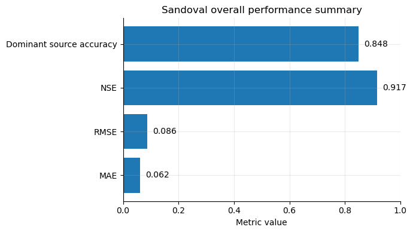

```python
# Overall performance summary

performance_summary = pd.DataFrame({
    "metric": [
        "MAE",
        "RMSE",
        "NSE",
        "Dominant source accuracy",
    ],
    "value": [
        metrics.loc[0, "mae"],
        metrics.loc[0, "rmse"],
        metrics.loc[0, "nse"],
        metrics.loc[0, "dominant_source_accuracy"],
    ],
})

fig, ax = plt.subplots(figsize=(7, 4))

ax.barh(performance_summary["metric"], performance_summary["value"])
ax.set_xlabel("Metric value")
ax.set_title("Sandoval overall performance summary")
ax.set_xlim(0, 1)

for index, value in enumerate(performance_summary["value"]):
    ax.text(value + 0.02, index, f"{value:.3f}", va="center")

fig.tight_layout()
fig.savefig(figures_dir / "sandoval_overall_performance_summary.png", dpi=180)
plt.show()

performance_summary.to_csv(
    tables_dir / "sandoval_overall_performance_summary.csv",
    index=False,
)
```

### Estimated versus Known Proportions

This figure compares the estimated and known source proportions across all artificial mixtures. Points close to the one-to-one line indicate accurate source fraction recovery.

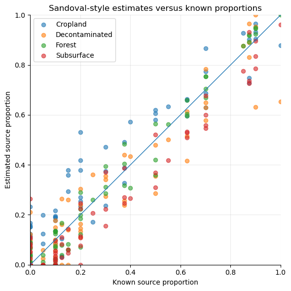

```python
# Estimated versus true source proportions

fig, ax = plt.subplots(figsize=(6, 6))

for source, group in sandoval_results.groupby("source_label"):
    ax.scatter(
        group["true_proportion"],
        group["estimated_proportion"],
        alpha=0.6,
        s=35,
        label=source,
    )

ax.plot([0, 1], [0, 1], linewidth=1)
ax.set_xlim(0, 1)
ax.set_ylim(0, 1)
ax.set_xlabel("Known source proportion")
ax.set_ylabel("Estimated source proportion")
ax.set_title("Sandoval-style estimates versus known proportions")
ax.legend()

fig.tight_layout()
fig.savefig(figures_dir / "sandoval_estimated_vs_true.png", dpi=180)
plt.show()
```

### Source-Level Error

The next two diagnostics separate magnitude of error from direction of error. Mean absolute error shows which sources are hardest to estimate, while mean error shows whether the model tends to overestimate or underestimate each source.

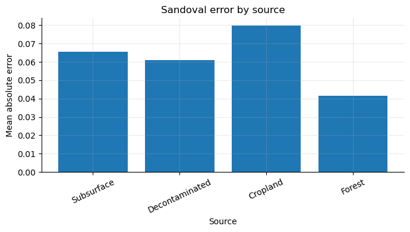

```python
# Source-level mean absolute error

fig, ax = plt.subplots(figsize=(7, 4))

ax.bar(source_metrics["source_label"], source_metrics["mae"])
ax.set_xlabel("Source")
ax.set_ylabel("Mean absolute error")
ax.set_title("Sandoval error by source")
ax.tick_params(axis="x", rotation=25)

fig.tight_layout()
fig.savefig(figures_dir / "sandoval_error_by_source.png", dpi=180)
plt.show()
```

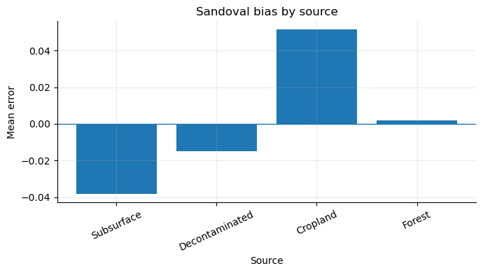

```python
# Source-level mean error

fig, ax = plt.subplots(figsize=(7, 4))

ax.bar(source_metrics["source_label"], source_metrics["mean_error"])
ax.axhline(0, linewidth=1)
ax.set_xlabel("Source")
ax.set_ylabel("Mean error")
ax.set_title("Sandoval bias by source")
ax.tick_params(axis="x", rotation=25)

fig.tight_layout()
fig.savefig(figures_dir / "sandoval_bias_by_source.png", dpi=180)
plt.show()
```

### Representative Compositions

A small set of representative mixtures is shown to make the compositional predictions easier to inspect. The examples are selected among the mixtures with the largest mean absolute errors, because these cases are the most informative for diagnosing limitations of the method.

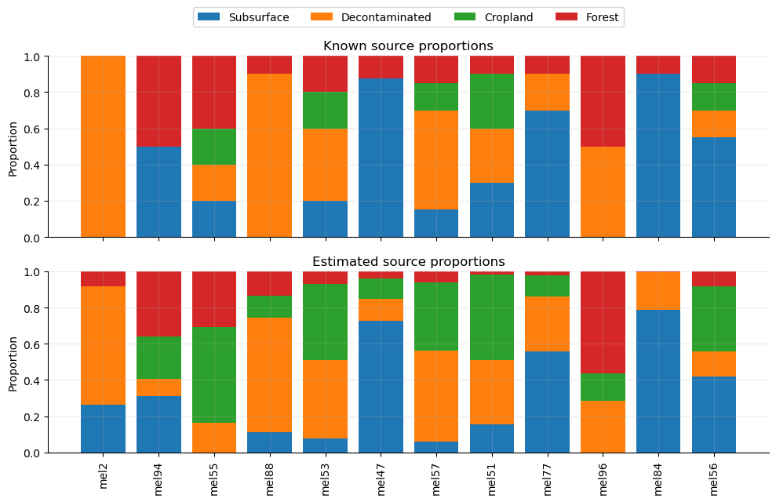

```python
# Known and estimated compositions for representative mixtures

n_examples = min(12, len(predicted_wide))

example_samples = (
    sample_metrics
    .sort_values("mean_absolute_error", ascending=False)
    .head(n_examples)["sample"]
    .tolist()
)

comparison_long = []

for sample in example_samples:
    for source in source_order:
        comparison_long.append({
            "sample": sample,
            "source_label": source,
            "type": "Known",
            "proportion": truth_wide.loc[sample, source],
        })
        comparison_long.append({
            "sample": sample,
            "source_label": source,
            "type": "Estimated",
            "proportion": predicted_wide.loc[sample, source],
        })

comparison_long = pd.DataFrame(comparison_long)

fig, axes = plt.subplots(2, 1, figsize=(10, 6.5), sharex=True)

for ax, label in zip(axes, ["Known", "Estimated"]):
    bottom = np.zeros(n_examples)
    data = (
        comparison_long
        .query("type == @label")
        .pivot(index="sample", columns="source_label", values="proportion")
        .reindex(index=example_samples, columns=source_order)
    )

    for source in source_order:
        ax.bar(np.arange(n_examples), data[source], bottom=bottom, label=source)
        bottom += data[source].to_numpy()

    ax.set_ylim(0, 1)
    ax.set_ylabel("Proportion")
    ax.set_title(f"{label} source proportions")

axes[-1].set_xticks(np.arange(n_examples), labels=example_samples, rotation=90)
axes[0].legend(ncol=4, loc="upper center", bbox_to_anchor=(0.5, 1.3))

fig.tight_layout()
fig.savefig(figures_dir / "sandoval_known_vs_estimated_representative_compositions.png", dpi=180)
plt.show()
```

### Dominant-Source Classification

The dominant-source confusion matrix evaluates whether the method correctly identifies the largest contributing source in each mixture. This diagnostic is useful because, in many environmental applications, identifying the dominant source may be as important as estimating the full composition exactly.

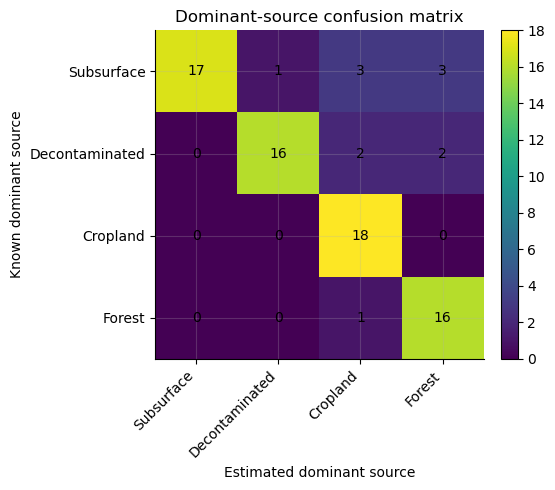

```python
# Dominant-source confusion matrix

fig, ax = plt.subplots(figsize=(6, 5))

image = ax.imshow(dominant_confusion.to_numpy())

ax.set_xticks(np.arange(len(source_order)), labels=source_order, rotation=45, ha="right")
ax.set_yticks(np.arange(len(source_order)), labels=source_order)
ax.set_xlabel("Estimated dominant source")
ax.set_ylabel("Known dominant source")
ax.set_title("Dominant-source confusion matrix")

for i in range(dominant_confusion.shape[0]):
    for j in range(dominant_confusion.shape[1]):
        ax.text(
            j,
            i,
            int(dominant_confusion.iloc[i, j]),
            ha="center",
            va="center",
        )

fig.colorbar(image, ax=ax, fraction=0.046, pad=0.04)

fig.tight_layout()
fig.savefig(figures_dir / "sandoval_dominant_source_confusion_matrix.png", dpi=180)
plt.show()
```

### Tracer and Ratio Residuals

The tracer residuals show how well the final estimated fractions reproduce the scaled tracer signatures. The log-ratio residuals inspect the objective function more directly and help identify whether specific tracer pairs are difficult to reconcile under the ratio-based formulation.

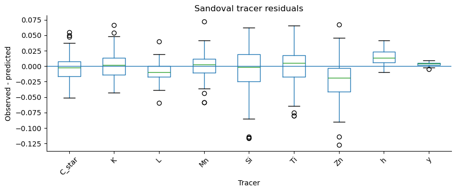

```python
# Residuals by tracer

fig, ax = plt.subplots(figsize=(9, 4))

residuals.boxplot(
    column="residual",
    by="tracer",
    ax=ax,
    grid=False,
    rot=45,
)

ax.axhline(0, linewidth=1)
ax.set_title("Sandoval tracer residuals")
ax.set_xlabel("Tracer")
ax.set_ylabel("Observed - predicted")
fig.suptitle("")

fig.tight_layout()
fig.savefig(figures_dir / "sandoval_residuals_by_tracer.png", dpi=180)
plt.show()
```

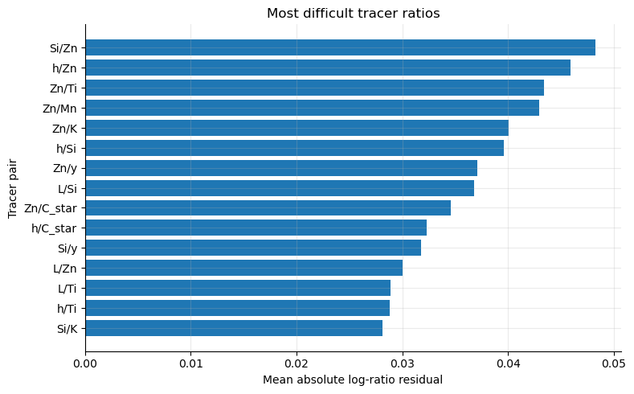

```python
# Largest absolute log-ratio residuals by tracer pair

ratio_pair_summary = (
    ratio_residuals
    .assign(abs_log_ratio_residual=lambda df: df["log_ratio_residual"].abs())
    .groupby("ratio_pair", as_index=False)
    .agg(mean_abs_log_ratio_residual=("abs_log_ratio_residual", "mean"))
    .sort_values("mean_abs_log_ratio_residual", ascending=False)
    .head(15)
)

fig, ax = plt.subplots(figsize=(8, 5))

ax.barh(
    ratio_pair_summary["ratio_pair"],
    ratio_pair_summary["mean_abs_log_ratio_residual"],
)
ax.invert_yaxis()
ax.set_xlabel("Mean absolute log-ratio residual")
ax.set_ylabel("Tracer pair")
ax.set_title("Most difficult tracer ratios")

fig.tight_layout()
fig.savefig(figures_dir / "sandoval_difficult_tracer_ratios.png", dpi=180)
plt.show()

ratio_pair_summary.to_csv(
    tables_dir / "sandoval_difficult_tracer_ratios.csv",
    index=False,
)
```

## Final Remarks

The Sandoval-style ratio-based model provides a second deterministic baseline for sediment source apportionment. Instead of matching absolute tracer concentrations directly, it estimates source fractions by matching pairwise relationships among selected tracers.

This formulation is useful because it tests whether relative tracer structure contains enough information to recover the source composition of artificial mixtures. If the method performs well, it suggests that source discrimination is not only driven by absolute concentration levels, but also by stable multivariate relationships among tracers.

At the same time, the method should be interpreted carefully. Pairwise ratios are not independent, and the deterministic formulation does not quantify uncertainty in the estimated source contributions. For that reason, the Sandoval-style model is best used as a complementary baseline alongside the McCaffrey-style constrained least-squares model and the stochastic sediment fingerprinting workflow.